# vivekvajipey_A4

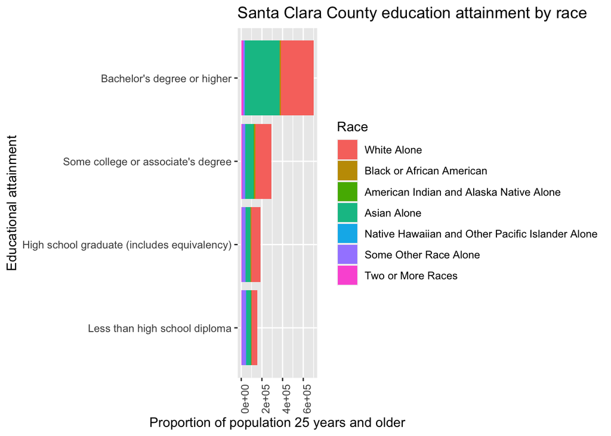

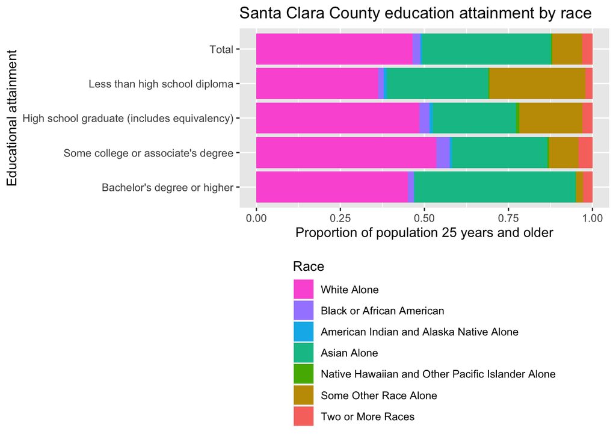

In Santa Clara County, 54% of the population over 25 is non-white and 57% of the population over 25 with a high school graduate education or lower is non-white, which fairly close. However, the population over 25 with an education strictly less than a high school diploma is 64% non-white, and non-white individuals seem to be 19% more likely to not have a high school education than expected. For many jobs, a baseline of a high school education is required, which narrows the set of available opportunities for the non-white population in this lowest education tier. The data represent the education of individuals older than 25 and many individuals who complete high school and a potential associate’s/bachelor’s degree before turning 25, so these data generally represent the highest education to be attained by the individual. It may be insightful to consider the effects of wealth and income on the educational disparities between races, especially since much of Santa Clara county is wealthy.

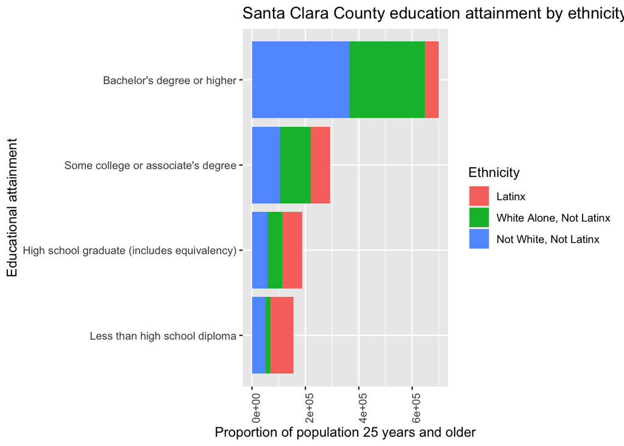

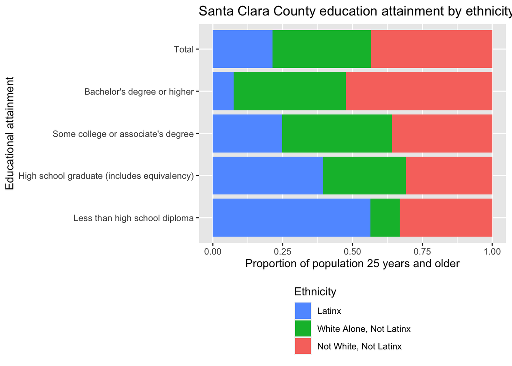

…

In Santa Clara County, 21% of the population over 25 is Latinx, 43% of the population over 25 is neither white nor Latinx and 35% of the population over 25 is white alone and not Latinx. However, the population over 25 with an education of a high school degree or lower is 47% Latinx. The statistics are even further from the overall population percentages for the population with an education strictly less than a high school diploma, which is 56% Latinx and only 10% white alone and not Latinx.